# Большое практическое задание 2

## Эксперименты (13 баллов)

### 1. Исследование параметров градиентного спуска (3 балла)

В спецификации предлагается использовать следующую формулу для выбора темпа обучения $\eta_k$:

$$\eta_k = \frac{\alpha}{k^{\beta}}, \quad \text{где $\alpha$, $\beta$ - заданные константы}, \; \text{$k$ - номер итерации}$$

Исследуйте поведение градиентного спуска для задачи логистической регрессии в зависимости от следующих параметров:

- параметр темпа обучения `step_alpha`
- параметр темпа обучения `step_beta`

Исследование поведения подразумевает анализ следующих зависимостей на обучающей и валидационной выборках:

- зависимость значения функции потерь от реального времени работы метода
- зависимость значения функции потерь от эпохи метода
- значение метрики качества после обучения метода

В качестве метрики качества здесь и далее предлагается использовать сбалансированную точность (balanced accuracy), реализацию, совместимую с множеством меток $\{−1, 1\}$, можно найти в модуле `utils`.

**Замечание.** Для оценки времени долго работающих функций можно пользоваться либо функциями из модуля `time`, либо magic-командой `%time`, которая запускает код лишь один раз.

#### Приведите график / таблицу с результатами ваших экспериментов

```python
alpha = [0.1,0.3, 0.5, 0.7, 1]
```

```python
beta = [0.1,0.3, 0.5, 0.7, 1]
```

```python
loss_function = BinaryLogisticLoss(l2_coef=0)
print("Зависимость функции потерь от времени работы метода, + метрика качетсва, после обучения")

for a in alpha:
    for b in beta:
        linear_model = LinearModel(
    loss_function=loss_function,
    batch_size=None,
    step_alpha=a,
    step_beta=b,
    max_iter = 200,
)

        t =  %timeit -o -q -r 1 linear_model.fit(X_train_tfidf_bias, y_train)

        los_train = linear_model.get_objective(X_train_tfidf_bias,y_train)
        los_val = linear_model.get_objective(X_val_tfidf_bias,y_val)

        threshold_val = linear_model.get_optimal_threshold(X_val_tfidf_bias, y_val)

        y_pred_train = linear_model.predict(X_train_tfidf_bias,threshold_val)
        accuracy_train = compute_balanced_accuracy(y_train,y_pred_train)

        y_pred_val = linear_model.predict(X_val_tfidf_bias,threshold_val)
        accuracy_val = compute_balanced_accuracy(y_val,y_pred_val)

        print("a =",a,"b =",b,"time_fit =","{:.4f}".format(t.best))
        print("Train set")
        print("log_loss =", "{:.4f}".format(los_train), "accuracy =","{:.4f}".format(accuracy_train))

        print("Validation set")
        print("log_loss =", "{:.4f}".format(los_val), "accuracy =","{:.4f}".format(accuracy_val))
        print()
```

```
Зависимость функции потерь от времени работы метода, + метрика качетсва, после обучения
a = 0.1 b = 0.1 time_fit = 11.8179
Train set
log_loss = 0.4350 accuracy = 0.5000
Validation set
log_loss = 0.4348 accuracy = 0.5003

a = 0.1 b = 0.3 time_fit = 12.0223
Train set
log_loss = 0.6870 accuracy = 0.4998
Validation set
log_loss = 0.6856 accuracy = 0.5005

a = 0.1 b = 0.5 time_fit = 14.8988
Train set
log_loss = 1.1960 accuracy = 0.4996
Validation set
log_loss = 1.1924 accuracy = 0.5002

a = 0.1 b = 0.7 time_fit = 11.9466
Train set
log_loss = 1.7135 accuracy = 0.5000
Validation set
log_loss = 1.7086 accuracy = 0.5003

a = 0.1 b = 1 time_fit = 12.3455
Train set
log_loss = 2.3416 accuracy = 0.4990
Validation set
log_loss = 2.3337 accuracy = 0.5002

a = 0.3 b = 0.1 time_fit = 12.4681
Train set
log_loss = 0.3992 accuracy = 0.4998
Validation set
log_loss = 0.4000 accuracy = 0.5005

a = 0.3 b = 0.3 time_fit = 12.1052
Train set
log_loss = 0.4205 accuracy = 0.4997
```

[output cut: 89 more lines]

```
log_loss = 0.3965 accuracy = 0.4994
Validation set
log_loss = 0.3972 accuracy = 0.5006

a = 1 b = 0.5 time_fit = 13.6556
Train set
log_loss = 0.4009 accuracy = 0.4995
Validation set
log_loss = 0.4011 accuracy = 0.5005

a = 1 b = 0.7 time_fit = 14.7832
Train set
log_loss = 0.4410 accuracy = 0.4996
Validation set
log_loss = 0.4408 accuracy = 0.5003
```

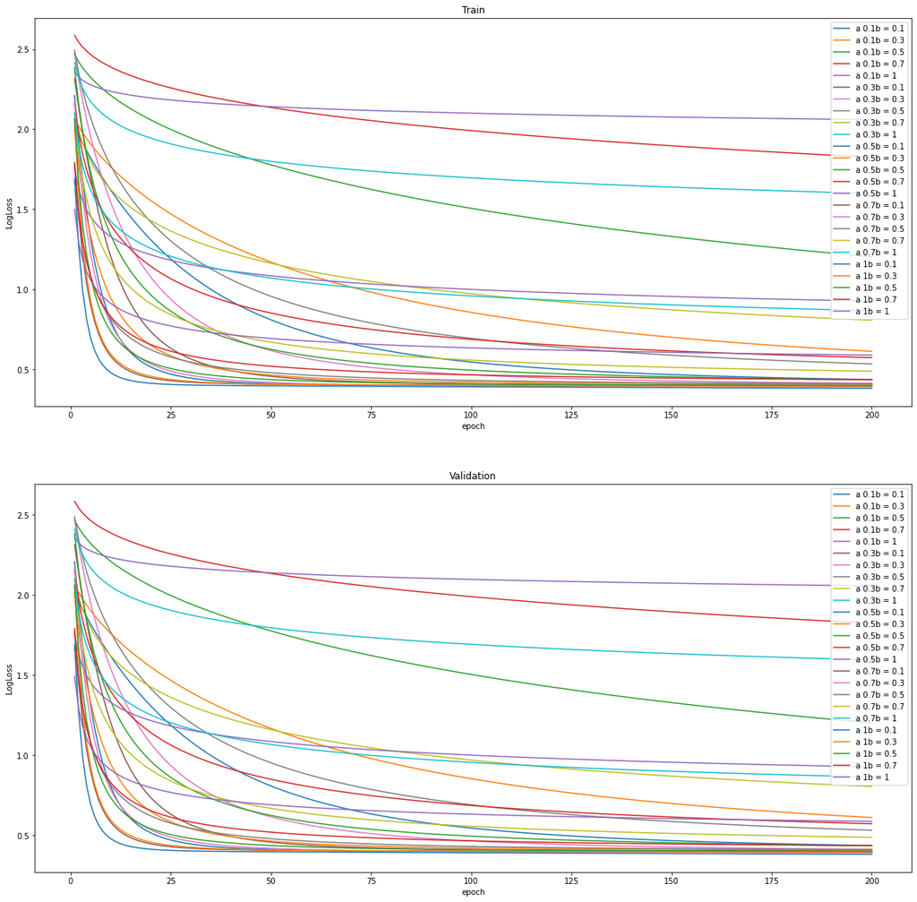

```python
loss_function = BinaryLogisticLoss(l2_coef=0)
f, axs = plt.subplots(2,figsize=(20,20))

for a in alpha:
    for b in beta:
        linear_model = LinearModel(
    loss_function=loss_function,
    batch_size=None,
    step_alpha=a,
    step_beta=b,
    max_iter = 200,
)
        hist = linear_model.fit(X_train_tfidf_bias, y_train, trace = True,
                                X_val = X_val_tfidf_bias, y_val =y_val)


        axs[0].plot(np.arange(1,201), hist['func'], label="a " + str(a) + "b = "+str(b))
        axs[1].plot(np.arange(1,201), hist['func_val'], label="a " + str(a) + "b = "+str(b))

axs[0].set_title('Train')
axs[1].set_title('Validation')


for ax in axs.flat:
    ax.set(xlabel='epoch', ylabel='LogLoss')
    ax.legend(loc="upper right")
```

```python
y[y==0].shape
```

```
(143323,)
```

```python
y[y==1].shape
```

```
(16225,)
```

#### Ответьте на следующие вопросы

1. По результатам экспериментов, какие параметры `step_alpha` и `step_beta` вы считаете наиболее оптимальными? Если пар оптимальных параметров получилось несколько, какую пару вы выберете для дальнейших экпериментов и почему?

   Считаю более оптимальной парой `step_alpha` = 1 и `step_beta` = 0.1, так как и на валидационной выборке, и на тренировочной, они показывают наименшьий лог-лосс и относительно высокую точность, так же на графиках можно заметить, что с этими парметрами, градиентный спуск сходится довольно быстро
1. Какие зависимости между параметрами `step_alpha`/`step_beta` и временем работы алгоритма/кол-ва эпох вы наблюдаете? Опишите свои наблюдения.

   Я предполагаю, что это связано с тем, что классы несбалансированы, нетоксичных комментриев (143323) намного больше, чем токсичных (16225)

### 2. Исследование параметров стахастического градиентного спуска (3 балла)

Исследуйте поведение стохастического градиентного спуска для задачи логистической регрессии в зависимости от следующих параметров:

- параметр темпа обучения `step_alpha`
- параметр темпа обучения `step_beta`
- размер подвыборки `batch_size`

**Замечание.** Обратите внимание, что в стохастическом случае необходимо строить зависимости метрик качества от эпохи метода. За одну эпоху через оптимизацию модели проходит $N$ объектов, где $N$ — длина обучающей выборки. Если вы реализуете семплирование согласно спецификации задания, то за одну эпоху каждый объект пройдёт через оптимизацию ровно один раз. В полном градиентном спуске одна эпоха метода соответствует одной итерации обучения.

#### Приведите график / таблицу с результатами ваших экспериментов

```python
alpha = [0.1, 0.5, 0.7, 1]
beta = [0.1, 0.5, 0.7, 1]
b_size = [1000,10000,100000]
```

```python
loss_function = BinaryLogisticLoss(l2_coef=0)
print("Зависимость функции потерь от времени работы метода, + метрика качетсва, после обучения")
for a in alpha:
    for b in beta:
        for size in b_size:
            linear_model = LinearModel(
        loss_function=loss_function,
        batch_size=size,
        step_alpha=a,
        step_beta=b,
        max_iter = 100,
        )

            t =  %timeit -o -q -r 1 linear_model.fit(X_train_tfidf_bias, y_train)

            los_train = linear_model.get_objective(X_train_tfidf_bias,y_train)
            los_val = linear_model.get_objective(X_val_tfidf_bias,y_val)


            threshold_val = linear_model.get_optimal_threshold(X_val_tfidf_bias, y_val)

            y_pred_train = linear_model.predict(X_train_tfidf_bias, threshold_train, threshold_val)
            accuracy_train = compute_balanced_accuracy(y_train,y_pred_train)

            y_pred_val = linear_model.predict(X_val_tfidf_bias, threshold_val, threshold_val)
            accuracy_val = compute_balanced_accuracy(y_val,y_pred_val)

            print("a =",a,"b =",b,"batch_size =",size, "time_fit =","{:.4f}".format(t.best))

            print("Train set")
            print("log_loss =", "{:.4f}".format(los_train), "accuracy =","{:.4f}".format(accuracy_train))

            print("Validation set")
            print("log_loss =", "{:.4f}".format(los_val), "accuracy =","{:.4f}".format(accuracy_val))
            print()
```

[output not shown]

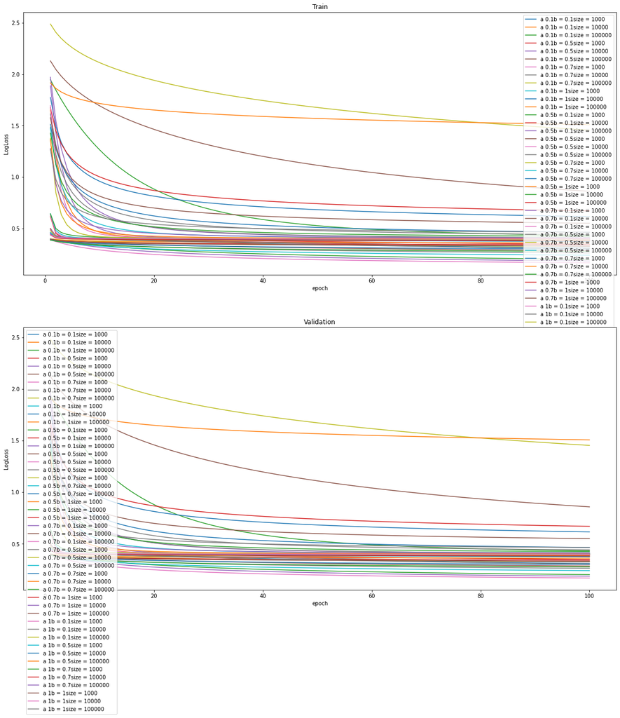

```python
loss_function = BinaryLogisticLoss(l2_coef=0)
f, axs = plt.subplots(2,figsize=(20,20))

for a in alpha:
    for b in beta:
        for size in b_size:
            linear_model = LinearModel(
        loss_function=loss_function,
        batch_size=size,
        step_alpha=a,
        step_beta=b,
        max_iter = 100,
        )
            hist = linear_model.fit(X_train_tfidf_bias, y_train, trace = True,
                                X_val = X_val_tfidf_bias, y_val =y_val)

            axs[0].plot(np.arange(1,101), hist['func'], label="a " + str(a) + "b = "+str(b)+
                    "size = "+ str(size))

            axs[1].plot(np.arange(1,101), hist['func_val'], label="a " + str(a) + "b = "+str(b)+
                    "size = "+ str(size))

axs[0].set_title('Train')
axs[1].set_title('Validation')

axs[0].legend(loc="upper right")
axs[1].legend(loc="upper left")


for ax in axs.flat:
    ax.set(xlabel='epoch', ylabel='LogLoss')
```

#### Ответьте на следующие вопросы

1. По результатам экспериментов, какие параметры `step_alpha`, `step_beta` и `batch_size` вы считаете наиболее оптимальными? Если троек оптимальных параметров получилось несколько, какую пару вы выберете для дальнейших экпериментов и почему?

   Насчет `step_alpha` и `step_beta`, лучше всего показали себя те же самые константы, что и в предыдущем эксперименте, то есть `step_alpha` = 1, `step_beta` = 0.1, так как у этой пары вновь лучшие метрики. Из экспериментов можно заметить, что чаще лучшие показатели были при минимально возможным размере батча, то есть при `batch_size` = 1000
1. Какие зависимости между параметрами `step_alpha`/`step_beta`/`batch_size` и временем работы алгоритма/кол-ва эпох вы наблюдаете? Опишите свои наблюдения.

### 3. Сравнение двух методов (2 балла)

Сравните поведение двух методов между собой, и ответьте на следующие вопросы

1. Какой алгоритм вы выберете для дальнейших экспериментов и почему?

### 4. Регуляризация (2 балла)

Подберите по отложенной выборке коэффициент $l2$-регуляризации модели.

Приведите график с результатами ваших экспериментов. Обоснуйте свой выбор.

```python
coefs = [0, 0.1,0.4,0.7,0.9, 1]
accuracy = []
```

```python
for l in coefs:
    loss_function = BinaryLogisticLoss(l2_coef=l)
    linear_model = LinearModel(
    loss_function=loss_function,
    batch_size=1000,
    step_alpha=1,
    step_beta=0.1,
    max_iter = 100,
    )

    linear_model.fit(X_train_tfidf_bias, y_train)
    y_pred_val = linear_model.predict(X_val_tfidf_bias)
    accuracy.append(compute_balanced_accuracy(y_val,y_pred_val))
```

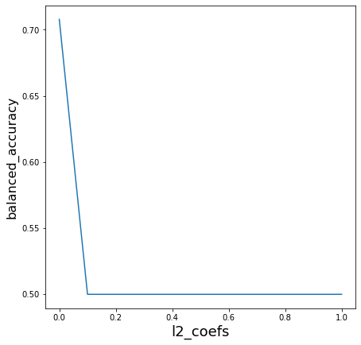

```python
fig = plt.figure(figsize=(7, 7))
plt.plot(coefs, accuracy, label="log_loss")
plt.xlabel('l2_coefs', fontsize=18)
plt.ylabel('balanced_accuracy', fontsize=16)
```

Далее буду проводить, эксперименты без коэфициента регулязации, так как с ним сильно падает accuracy

### 5. Измерение качества и интерпретация результатов (3 балла)

Выберите лучший алгоритм для тестовой выборки. Обратите внимание, что необходимо использовать порог бинаризации, выбранный на отложенной выборке.

```python
threshold = linear_model.get_optimal_threshold(X_val_tfidf_bias, y_val)
```

```python
loss_function = BinaryLogisticLoss(l2_coef=0.0)
linear_model = LinearModel(
loss_function=loss_function,
batch_size=1000,
step_alpha=1,
step_beta=0.1,
max_iter = 500,
)

linear_model.fit(X_train_tfidf_bias, y_train)
```

```python
threshold = linear_model.get_optimal_threshold(X_val_tfidf_bias, y_val)
```

```python
y_pred = linear_model.predict(X_val_tfidf_bias, threshold)
print("Validation accuracy =", compute_balanced_accuracy(y_val,y_pred))
```

```
Validation accuracy = 0.9024026522704636
```

```python
y_pred = linear_model.predict(X_test_tfidf_bias, threshold)
print("Test accuracy =",compute_balanced_accuracy(y_test,y_pred))
```

```
Test accuracy = 0.8857356077925427
```

```python
errors = y_pred != y_test
```

```python
print("comments")
for i, w in enumerate(test["comment_text_alpha_numeric"][errors][:10]):
    print(w)
    if y_pred[errors][i] == -1:

        print("predicted = not toxic")
    else:
        print("predicted = toxic")

    if y_test[errors][i] == -1:
        print("actually = not toxic")
    else:
        print("actually = toxic")

    print("--------------")
```

```
comments
 dear god this site is horrible
predicted = toxic
actually = not toxic
--------------
               jews are not a race because you can only get it from your mother  your own mention of ethiopian jews not testing             as jews proves it is not  as well as the fact that we accept converts
predicted = toxic
actually = not toxic
--------------
       balance     this page has one sentence about the basic definition of the word  and a huge amount about the slang profane uses  perhaps the former should be extended  is there no information about female dogs available beyond their name  this is an encyclopaedia  not a dictionary         i fee…
predicted = toxic
actually = not toxic
--------------
i will burn you to hell if you revoke my talk page access
predicted = toxic
actually = not toxic
--------------
      use of   assisted suicide   to refer to aid in dying is inaccurate in fourth distinctive ways  first  it was coined by catholic activists disputing oregon s measure 16 in 1994   so it carries a political bias  second  the laws in oregon  washington and vermont each do not contain the term   as…
predicted = toxic
actually = not toxic
--------------
avg  plenty of greeks love the king  stop acting like all greeks hate him  you just parrot what the government tells us via their  media   we greeks asked george i to be our king  we supported them  they reclaimed much of our lands  we voted to keep them numerous times  in the 1930 s by 97  vote    …
predicted = toxic
actually = not toxic
--------------
 this is just bizarre  ani medjool s abuse of wikipedia rules gets rewarded  and then he awards you a barnstar   wtf   anyhow a new person  adept at ridicule  has joined in the conversation at falafel   sigh
predicted = toxic
actually = not toxic
--------------
   black mamba       it is ponious snake of the word and but it not kills many people but king cobra kills many people in india
predicted = toxic
actually = not toxic
--------------
  i just revamped wp fart  i thought a little housekeeping would give it more street cred
predicted = toxic
actually = not toxic
--------------
        shameless canvass       hello  diannaa  thanks for blocking that horrible puke again  when i   translate    on your page i get mad  he is just a total piece of garbage  thanks again
predicted = toxic
actually = not toxic
--------------
```

```python
print("lemmatize comments")
for i, w in enumerate(X_test[errors][:10]):
    print(w)
    if y_pred[errors][i] == -1:

        print("predicted = not toxic")
    else:
        print("predicted = toxic")

    if y_test[errors][i] == -1:
        print("actually = not toxic")
    else:
        print("actually = toxic")

    print("--------------")
```

```
lemmatize comments
dear god site horrible
predicted = toxic
actually = not toxic
--------------
jew race get mother mention ethiopian jew test jew prof well fact accept convert
predicted = toxic
actually = not toxic
--------------
balance page one sentence basic definition word huge amount slang profane us perhaps former extend information female dog available beyond name encyclopaedia dictionary feel whoever look definition appropiate delete wikipedia immediatly word use often also mean word belive majorly true much okay goo…
predicted = toxic
actually = not toxic
--------------
burn hell revoke talk page access
predicted = toxic
actually = not toxic
--------------
use assist suicide refer aid die inaccurate fourth distinctive way first coin catholic activist dispute oregon measure 16 1994 carry political bias second law oregon washington vermont contain term assist suicide use aid die third assist suicide remains illegal three state also montana new mexico st…
predicted = toxic
actually = not toxic
--------------
avg plenty greek love king stop act like greek hate parrot government tell u via medium greek ask george king support reclaim much land vote keep numerous time 1930 97 vote also try overthrow dictator read book greek government big liar u want u king claim constantinople asia minor direct descendant…
predicted = toxic
actually = not toxic
--------------
bizarre ani medjool abuse wikipedia rule get reward award barnstar wtf anyhow new person adept ridicule join conversation falafel sigh
predicted = toxic
actually = not toxic
--------------
black mamba ponious snake word kill many people king cobra kill many people india
predicted = toxic
actually = not toxic
--------------
revamped wp fart thought little housekeep would give street cred
predicted = toxic
actually = not toxic
--------------
shameless canvas hello diannaa thanks block horrible puke translate page get mad total piece garbage thanks
predicted = toxic
actually = not toxic
--------------
```

#### Ответьте на следующие вопросы

1. Примените лучший алгоритм к тестовой выборке и посмотрите на метрику качества. Сравните ее с метрикой на валидации. Опишите ваши наблюдения.

   accuracy довольно высокая на обоих выборках, значит скорее всего мы подобрали оптимальные параметры для обучения, а также не переобучились на тренировочной выборке
1. Проанализируйте ошибки алгоритма. Проанализируйте и укажите общие черты объектов, на которых были допущены ошибки. Наблюдения опишите.

   Некоторые комментраи - это просто набор символов, неудивительно, что модель на них ошибалась, по поводу остальной части, в некоторых комментраиях можно увидеть оскорбляющие слова по типу: 'hell', 'abuse', 'wtf' но если посмотреть на исходный комментрий, то эти слова были в контексте, и не хотел никого осокрблять. Можно сделать вывод, что скорее всего модель, довольно сильно натренировалась, на некоторых словах, (например mention или blind, hate ниже показано) таким образом, что если они есть в комментрии, то комментрию давался вес токсичности

```python
weights = (linear_model.model_weights)
words = tf.get_feature_names()
```

```python
for i, w in enumerate(words):
    if w=="mention":
        print("mention", weights[i])
    if w=="blind":
        print("blind", weights[i])
    if w=="wtf":
        print("wtf", weights[i])
    if w=="hate":
        print("hate", weights[i])
```

```
blind 0.30152557917274897
hate 1.0797012287692134
mention 2.0377013747058226
wtf 0.20727991252657402
```

```python
top_w_inds= np.argsort(weights)
```

```python
high_coefs = top_w_inds[-60:]
high_coefs = high_coefs[::-1]
low_coefs = top_w_inds[:60]
```

```python
np.sort(weights)[-60:]
```

```
array([ 3.08419318,  3.10527172,  3.12855655,  3.17093492,  3.26845307,
        3.334573  ,  3.34843752,  3.34914647,  3.42103649,  3.441181  ,
        3.47787475,  3.53696251,  3.59431507,  3.59746026,  3.65995914,
        3.67605217,  3.7707953 ,  3.77485889,  3.88911246,  3.89937342,
        3.92494753,  4.02202974,  4.03374997,  4.08283722,  4.23202903,
        4.35442667,  4.43307875,  4.44234175,  4.51875268,  4.54841874,
        4.74291966,  4.81801631,  4.84176667,  5.11117429,  5.30977507,
        5.34822142,  5.39379499,  5.47665801,  5.52989663,  5.69256257,
        5.70403259,  5.92234128,  6.13637826,  6.14452263,  6.20999669,
        6.68362345,  6.83098947,  7.20346322,  7.26479659,  7.70486512,
        7.82230044,  8.3216669 ,  8.66618911,  9.36995561, 10.1404339 ,
       10.50006801, 11.65225059, 11.84111498, 12.01591974, 20.2605736 ])
```

```python
for i in high_coefs:
    print(words[i])
```

```
fucken
idiotic
shite
stupidest
sucker
asap
assign
bitching
dickhead
crappy
fagot
cup
bully
moronic
hello
penn
gaza
bat
jerome
retarted
loses
night
faggot
shutdown
pathetically
damon
hateful
cockroach
rack
dumbass
pistol
fooling
fuckface
killer
wu
ignore
dumbed
sexist
put
fatal
nerdy
lib
fucktard
diego
nazism
sicken
wanna
motherfucking
dish
arsed
whose
scribble
homosexuality
pigeon
stupidly
dicklyon
uh
dis
douchebag
holiday
```

```python
for i in low_coefs:
    print(words[i])
```

```
thanksgiving
articulate
00
pleased
thanked
wouldnt
south
mentor
useful
maya
booker
pointer
sectioneer
couldnt
utf
talk2me
ist
statehood
redirection
listas
bestow
helper
considerable
seed
inclusion
alt
casey
continued
tx
leader
require
agreeable
firsthand
numbered
referendum
terminal
workable
seemingly
reviewer
addendum
mighty
wqa
grouped
sort
deletionist
tito
regardless
linkage
onepage
goodbye
exceed
supporter
disdain
movement
evident
surely
taht
needle
parthian
newbie
```

1. Проинтерпретируйте линейные коэффициенты признаков. Выберите коэффициенты с набиольшим значением и коэффициенты с наименьшим значением. Проанализируйте, каким словам они соответствуют. Согласуются ли ваши наблюдения с вашими ожиданиями от модели?